# Risk Factor Analysis

## Outcome Variable

**Outcome Variable:** y_rate_lencm

## Predictor Variables

**Intervention Variable:** gagebrth

**Adjustment Set:**

unadjusted

## Stratifying Variables

The analysis was stratified on these variable(s):

- diffcat
- studyid
- country

## Data Summary

| diffcat | studyid | country | gagebrth | n_cell | n |
| --- | --- | --- | --- | --- | --- |
| 0-3 months | ki1017093c-NIH-Crypto | BANGLADESH | [273-287) | 239 | 720 |
| 0-3 months | ki1017093c-NIH-Crypto | BANGLADESH | <259 | 148 | 720 |
| 0-3 months | ki1017093c-NIH-Crypto | BANGLADESH | [259-273) | 315 | 720 |
| 0-3 months | ki1017093c-NIH-Crypto | BANGLADESH | >=287 | 18 | 720 |
| 3-6 months | ki1017093c-NIH-Crypto | BANGLADESH | [273-287) | 226 | 695 |
| 3-6 months | ki1017093c-NIH-Crypto | BANGLADESH | <259 | 144 | 695 |
| 3-6 months | ki1017093c-NIH-Crypto | BANGLADESH | [259-273) | 308 | 695 |
| 3-6 months | ki1017093c-NIH-Crypto | BANGLADESH | >=287 | 17 | 695 |
| 6-12 months | ki1017093c-NIH-Crypto | BANGLADESH | [273-287) | 215 | 676 |
| 6-12 months | ki1017093c-NIH-Crypto | BANGLADESH | <259 | 143 | 676 |
| 6-12 months | ki1017093c-NIH-Crypto | BANGLADESH | [259-273) | 301 | 676 |
| 6-12 months | ki1017093c-NIH-Crypto | BANGLADESH | >=287 | 17 | 676 |
| 12-24 months | ki1017093c-NIH-Crypto | BANGLADESH | [273-287) | 147 | 495 |
| 12-24 months | ki1017093c-NIH-Crypto | BANGLADESH | <259 | 106 | 495 |
| 12-24 months | ki1017093c-NIH-Crypto | BANGLADESH | [259-273) | 227 | 495 |
| 12-24 months | ki1017093c-NIH-Crypto | BANGLADESH | >=287 | 15 | 495 |
| 0-3 months | kiGH5241-JiVitA-3 | BANGLADESH | [273-287) | 5937 | 16862 |
| 0-3 months | kiGH5241-JiVitA-3 | BANGLADESH | <259 | 3173 | 16862 |
| 0-3 months | kiGH5241-JiVitA-3 | BANGLADESH | [259-273) | 4445 | 16862 |
| 0-3 months | kiGH5241-JiVitA-3 | BANGLADESH | >=287 | 3307 | 16862 |
| 3-6 months | kiGH5241-JiVitA-3 | BANGLADESH | [273-287) | 3388 | 9519 |
| 3-6 months | kiGH5241-JiVitA-3 | BANGLADESH | <259 | 1681 | 9519 |
| 3-6 months | kiGH5241-JiVitA-3 | BANGLADESH | [259-273) | 2493 | 9519 |
| 3-6 months | kiGH5241-JiVitA-3 | BANGLADESH | >=287 | 1957 | 9519 |
| 6-12 months | kiGH5241-JiVitA-3 | BANGLADESH | [273-287) | 2701 | 7559 |
| 6-12 months | kiGH5241-JiVitA-3 | BANGLADESH | <259 | 1359 | 7559 |
| 6-12 months | kiGH5241-JiVitA-3 | BANGLADESH | [259-273) | 1979 | 7559 |
| 6-12 months | kiGH5241-JiVitA-3 | BANGLADESH | >=287 | 1520 | 7559 |
| 12-24 months | kiGH5241-JiVitA-3 | BANGLADESH | [273-287) | 1278 | 3576 |
| 12-24 months | kiGH5241-JiVitA-3 | BANGLADESH | <259 | 681 | 3576 |

[output cut: 150 more lines]

The following strata were considered:

- diffcat: 0-3 months, studyid: ki1000108-CMC-V-BCS-2002, country: INDIA
- diffcat: 0-3 months, studyid: ki1000108-IRC, country: INDIA
- diffcat: 0-3 months, studyid: ki1000109-EE, country: PAKISTAN
- diffcat: 0-3 months, studyid: ki1000304b-SAS-CompFeed, country: INDIA
- diffcat: 0-3 months, studyid: ki1017093c-NIH-Crypto, country: BANGLADESH
- diffcat: 0-3 months, studyid: ki1101329-Keneba, country: GAMBIA
- diffcat: 0-3 months, studyid: ki1119695-PROBIT, country: BELARUS
- diffcat: 0-3 months, studyid: ki1135781-COHORTS, country: GUATEMALA
- diffcat: 0-3 months, studyid: ki1135781-COHORTS, country: INDIA
- diffcat: 0-3 months, studyid: kiGH5241-JiVitA-3, country: BANGLADESH
- diffcat: 12-24 months, studyid: ki1000108-CMC-V-BCS-2002, country: INDIA
- diffcat: 12-24 months, studyid: ki1000108-IRC, country: INDIA
- diffcat: 12-24 months, studyid: ki1017093c-NIH-Crypto, country: BANGLADESH
- diffcat: 12-24 months, studyid: ki1066203-TanzaniaChild2, country: TANZANIA, UNITED REPUBLIC OF
- diffcat: 12-24 months, studyid: ki1101329-Keneba, country: GAMBIA
- diffcat: 12-24 months, studyid: ki1113344-GMS-Nepal, country: NEPAL
- diffcat: 12-24 months, studyid: ki1119695-PROBIT, country: BELARUS
- diffcat: 12-24 months, studyid: ki1135781-COHORTS, country: GUATEMALA
- diffcat: 12-24 months, studyid: ki1135781-COHORTS, country: INDIA
- diffcat: 12-24 months, studyid: ki1135781-COHORTS, country: PHILIPPINES
- diffcat: 12-24 months, studyid: ki1148112-iLiNS-DYAD-M, country: MALAWI
- diffcat: 12-24 months, studyid: kiGH5241-JiVitA-3, country: BANGLADESH
- diffcat: 3-6 months, studyid: ki1000108-CMC-V-BCS-2002, country: INDIA
- diffcat: 3-6 months, studyid: ki1000108-IRC, country: INDIA
- diffcat: 3-6 months, studyid: ki1000109-EE, country: PAKISTAN
- diffcat: 3-6 months, studyid: ki1000304b-SAS-CompFeed, country: INDIA
- diffcat: 3-6 months, studyid: ki1017093c-NIH-Crypto, country: BANGLADESH
- diffcat: 3-6 months, studyid: ki1066203-TanzaniaChild2, country: TANZANIA, UNITED REPUBLIC OF
- diffcat: 3-6 months, studyid: ki1101329-Keneba, country: GAMBIA
- diffcat: 3-6 months, studyid: ki1113344-GMS-Nepal, country: NEPAL
- diffcat: 3-6 months, studyid: ki1119695-PROBIT, country: BELARUS
- diffcat: 3-6 months, studyid: ki1135781-COHORTS, country: GUATEMALA
- diffcat: 3-6 months, studyid: ki1135781-COHORTS, country: INDIA
- diffcat: 3-6 months, studyid: ki1148112-iLiNS-DYAD-M, country: MALAWI
- diffcat: 3-6 months, studyid: kiGH5241-JiVitA-3, country: BANGLADESH
- diffcat: 6-12 months, studyid: ki1000108-CMC-V-BCS-2002, country: INDIA
- diffcat: 6-12 months, studyid: ki1000108-IRC, country: INDIA
- diffcat: 6-12 months, studyid: ki1000109-EE, country: PAKISTAN
- diffcat: 6-12 months, studyid: ki1000304b-SAS-CompFeed, country: INDIA
- diffcat: 6-12 months, studyid: ki1017093c-NIH-Crypto, country: BANGLADESH
- diffcat: 6-12 months, studyid: ki1066203-TanzaniaChild2, country: TANZANIA, UNITED REPUBLIC OF
- diffcat: 6-12 months, studyid: ki1101329-Keneba, country: GAMBIA
- diffcat: 6-12 months, studyid: ki1113344-GMS-Nepal, country: NEPAL
- diffcat: 6-12 months, studyid: ki1119695-PROBIT, country: BELARUS
- diffcat: 6-12 months, studyid: ki1135781-COHORTS, country: GUATEMALA
- diffcat: 6-12 months, studyid: ki1135781-COHORTS, country: INDIA
- diffcat: 6-12 months, studyid: ki1135781-COHORTS, country: PHILIPPINES
- diffcat: 6-12 months, studyid: ki1148112-iLiNS-DYAD-M, country: MALAWI
- diffcat: 6-12 months, studyid: kiGH5241-JiVitA-3, country: BANGLADESH

### Dropped Strata

Some strata were dropped due to rare outcomes:

- diffcat: 0-3 months, studyid: ki1000304b-SAS-CompFeed, country: INDIA
- diffcat: 3-6 months, studyid: ki1000304b-SAS-CompFeed, country: INDIA
- diffcat: 6-12 months, studyid: ki1000304b-SAS-CompFeed, country: INDIA
- diffcat: 3-6 months, studyid: ki1148112-iLiNS-DYAD-M, country: MALAWI
- diffcat: 3-6 months, studyid: ki1113344-GMS-Nepal, country: NEPAL
- diffcat: 6-12 months, studyid: ki1113344-GMS-Nepal, country: NEPAL
- diffcat: 12-24 months, studyid: ki1113344-GMS-Nepal, country: NEPAL
- diffcat: 0-3 months, studyid: ki1000109-EE, country: PAKISTAN
- diffcat: 3-6 months, studyid: ki1000109-EE, country: PAKISTAN
- diffcat: 6-12 months, studyid: ki1000109-EE, country: PAKISTAN
- diffcat: 12-24 months, studyid: ki1066203-TanzaniaChild2, country: TANZANIA, UNITED REPUBLIC OF

## Methods Detail

We’re interested in the causal parameters $E[Y_a]$ for all values of $a \in \mathcal{A}$. These parameters represent the mean outcome if, possibly contrary to fact, we intervened to set all units to have $A=a$. Under the randomization and positivity assumptions, these are identified by the statistical parameters $\psi_a=E_W[E_{Y|A,W}(Y|A=a,W)]$. In addition, we’re interested in the mean of $Y$, $E[Y]$ under no intervention (the observed mean). We will estimate these parameters by using SuperLearner to fit the relevant likelihood factors – $E_{Y|A,W}(Y|A=a,W)$ and $p(A=a|W)$, and then updating our likelihood fit using a joint TMLE.

For unadjusted analyses ($W=\{\}$), initial likelihoods were estimated using Lrnr_glm to estimate the simple $E(Y|A)$ and Lrnr_mean to estimate $p(A)$. For adjusted analyses, a small library containing Lrnr_glmnet, Lrnr_xgboost, and Lrnr_mean was used.

Having estimated these parameters, we will then use the delta method to estimate relative risks and attributable risks relative to a prespecified baseline level of $A$.

# Results Detail

## Results Plots

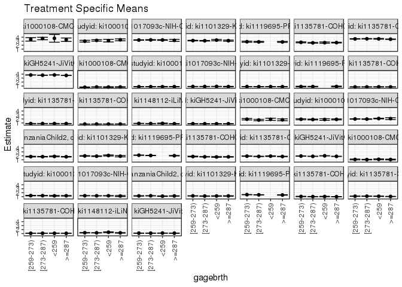

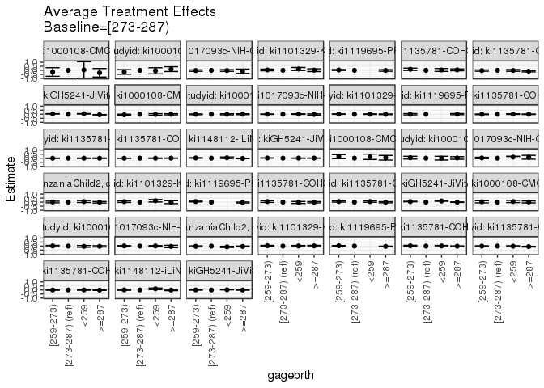

## Results Table

### Parameter: TSM

| diffcat | studyid | country | intervention_level | baseline_level | estimate | ci_lower | ci_upper |
| --- | --- | --- | --- | --- | --- | --- | --- |
| 0-3 months | ki1000108-CMC-V-BCS-2002 | INDIA | [273-287) | NA | 3.6711430 | 3.3648022 | 3.9774838 |
| 0-3 months | ki1000108-CMC-V-BCS-2002 | INDIA | <259 | NA | 3.7185385 | 2.7462427 | 4.6908344 |
| 0-3 months | ki1000108-CMC-V-BCS-2002 | INDIA | [259-273) | NA | 3.4606437 | 3.0266744 | 3.8946131 |
| 0-3 months | ki1000108-CMC-V-BCS-2002 | INDIA | >=287 | NA | 3.3656976 | 2.9335244 | 3.7978707 |
| 0-3 months | ki1000108-IRC | INDIA | [273-287) | NA | 3.1966508 | 3.0163529 | 3.3769487 |
| 0-3 months | ki1000108-IRC | INDIA | <259 | NA | 3.1370989 | 2.8052075 | 3.4689902 |
| 0-3 months | ki1000108-IRC | INDIA | [259-273) | NA | 2.9945321 | 2.7734810 | 3.2155833 |
| 0-3 months | ki1000108-IRC | INDIA | >=287 | NA | 3.3445718 | 3.1114916 | 3.5776519 |
| 0-3 months | ki1017093c-NIH-Crypto | BANGLADESH | [273-287) | NA | 3.3238284 | 3.2539964 | 3.3936603 |
| 0-3 months | ki1017093c-NIH-Crypto | BANGLADESH | <259 | NA | 3.3013573 | 3.2208049 | 3.3819098 |
| 0-3 months | ki1017093c-NIH-Crypto | BANGLADESH | [259-273) | NA | 3.2931090 | 3.2369760 | 3.3492419 |
| 0-3 months | ki1017093c-NIH-Crypto | BANGLADESH | >=287 | NA | 3.2076684 | 2.9484870 | 3.4668499 |
| 0-3 months | ki1101329-Keneba | GAMBIA | [273-287) | NA | 3.1074998 | 3.0321679 | 3.1828318 |
| 0-3 months | ki1101329-Keneba | GAMBIA | <259 | NA | 3.2694164 | 3.0974521 | 3.4413806 |
| 0-3 months | ki1101329-Keneba | GAMBIA | [259-273) | NA | 3.1536861 | 3.0832836 | 3.2240886 |
| 0-3 months | ki1101329-Keneba | GAMBIA | >=287 | NA | 3.1262713 | 2.9741597 | 3.2783829 |
| 0-3 months | ki1119695-PROBIT | BELARUS | [273-287) | NA | 2.8297970 | 2.7147204 | 2.9448737 |
| 0-3 months | ki1119695-PROBIT | BELARUS | [259-273) | NA | 2.8685210 | 2.7346196 | 3.0024224 |
| 0-3 months | ki1119695-PROBIT | BELARUS | >=287 | NA | 2.8122001 | 2.6931126 | 2.9312876 |
| 0-3 months | ki1135781-COHORTS | GUATEMALA | [273-287) | NA | 2.5861362 | 2.5096771 | 2.6625953 |
| 0-3 months | ki1135781-COHORTS | GUATEMALA | <259 | NA | 2.6282955 | 2.4693502 | 2.7872407 |
| 0-3 months | ki1135781-COHORTS | GUATEMALA | [259-273) | NA | 2.7134195 | 2.5903998 | 2.8364392 |
| 0-3 months | ki1135781-COHORTS | GUATEMALA | >=287 | NA | 2.6411735 | 2.5523037 | 2.7300432 |
| 0-3 months | ki1135781-COHORTS | INDIA | [273-287) | NA | 3.6024487 | 3.5488044 | 3.6560930 |
| 0-3 months | ki1135781-COHORTS | INDIA | <259 | NA | 3.5882972 | 3.4999458 | 3.6766486 |
| 0-3 months | ki1135781-COHORTS | INDIA | [259-273) | NA | 3.5727382 | 3.5078172 | 3.6376592 |
| 0-3 months | ki1135781-COHORTS | INDIA | >=287 | NA | 3.4934620 | 3.4278193 | 3.5591047 |
| 0-3 months | kiGH5241-JiVitA-3 | BANGLADESH | [273-287) | NA | 3.7237444 | 3.7079338 | 3.7395550 |
| 0-3 months | kiGH5241-JiVitA-3 | BANGLADESH | <259 | NA | 3.7834401 | 3.7599454 | 3.8069347 |
| 0-3 months | kiGH5241-JiVitA-3 | BANGLADESH | [259-273) | NA | 3.7743856 | 3.7551271 | 3.7936441 |

[output cut: 118 more lines]

### Parameter: E(Y)

| diffcat | studyid | country | intervention_level | baseline_level | estimate | ci_lower | ci_upper |
| --- | --- | --- | --- | --- | --- | --- | --- |
| 0-3 months | ki1000108-CMC-V-BCS-2002 | INDIA | NA | NA | 3.5424620 | 3.3226559 | 3.7622681 |
| 0-3 months | ki1000108-IRC | INDIA | NA | NA | 3.1786708 | 3.0648748 | 3.2924667 |
| 0-3 months | ki1017093c-NIH-Crypto | BANGLADESH | NA | NA | 3.3028656 | 3.2646714 | 3.3410598 |
| 0-3 months | ki1101329-Keneba | GAMBIA | NA | NA | 3.1443710 | 3.0969764 | 3.1917656 |
| 0-3 months | ki1119695-PROBIT | BELARUS | NA | NA | 2.8355739 | 2.7218468 | 2.9493011 |
| 0-3 months | ki1135781-COHORTS | GUATEMALA | NA | NA | 2.6275446 | 2.5773487 | 2.6777405 |
| 0-3 months | ki1135781-COHORTS | INDIA | NA | NA | 3.5676089 | 3.5348954 | 3.6003223 |
| 0-3 months | kiGH5241-JiVitA-3 | BANGLADESH | NA | NA | 3.7366791 | 3.7256757 | 3.7476826 |
| 3-6 months | ki1000108-CMC-V-BCS-2002 | INDIA | NA | NA | 1.8085894 | 1.7027345 | 1.9144443 |
| 3-6 months | ki1000108-IRC | INDIA | NA | NA | 1.8770590 | 1.8115784 | 1.9425395 |
| 3-6 months | ki1017093c-NIH-Crypto | BANGLADESH | NA | NA | 2.0057973 | 1.9693775 | 2.0422170 |
| 3-6 months | ki1066203-TanzaniaChild2 | TANZANIA, UNITED REPUBLIC OF | NA | NA | 1.7930234 | 1.7563473 | 1.8296994 |
| 3-6 months | ki1101329-Keneba | GAMBIA | NA | NA | 1.9509973 | 1.9060862 | 1.9959083 |
| 3-6 months | ki1119695-PROBIT | BELARUS | NA | NA | 2.0914863 | 2.0503474 | 2.1326251 |
| 3-6 months | ki1135781-COHORTS | GUATEMALA | NA | NA | 1.7551575 | 1.7203355 | 1.7899795 |
| 3-6 months | ki1135781-COHORTS | INDIA | NA | NA | 1.8699710 | 1.8423785 | 1.8975635 |
| 3-6 months | kiGH5241-JiVitA-3 | BANGLADESH | NA | NA | 1.9120583 | 1.8998349 | 1.9242816 |
| 6-12 months | ki1000108-CMC-V-BCS-2002 | INDIA | NA | NA | 1.0679211 | 1.0201335 | 1.1157087 |
| 6-12 months | ki1000108-IRC | INDIA | NA | NA | 1.2481465 | 1.2180063 | 1.2782868 |
| 6-12 months | ki1017093c-NIH-Crypto | BANGLADESH | NA | NA | 1.2281313 | 1.2106849 | 1.2455776 |
| 6-12 months | ki1066203-TanzaniaChild2 | TANZANIA, UNITED REPUBLIC OF | NA | NA | 1.1945105 | 1.1722780 | 1.2167429 |
| 6-12 months | ki1101329-Keneba | GAMBIA | NA | NA | 1.1776266 | 1.1570262 | 1.1982270 |
| 6-12 months | ki1119695-PROBIT | BELARUS | NA | NA | 1.4709224 | 1.4326640 | 1.5091808 |
| 6-12 months | ki1135781-COHORTS | GUATEMALA | NA | NA | 1.0213263 | 1.0014497 | 1.0412028 |
| 6-12 months | ki1135781-COHORTS | INDIA | NA | NA | 1.1028264 | 1.0847215 | 1.1209313 |
| 6-12 months | ki1135781-COHORTS | PHILIPPINES | NA | NA | 1.0678997 | 1.0556267 | 1.0801728 |
| 6-12 months | ki1148112-iLiNS-DYAD-M | MALAWI | NA | NA | 1.1960390 | 1.1724665 | 1.2196115 |
| 6-12 months | kiGH5241-JiVitA-3 | BANGLADESH | NA | NA | 1.1011985 | 1.0937157 | 1.1086814 |
| 12-24 months | ki1000108-CMC-V-BCS-2002 | INDIA | NA | NA | 0.7386817 | 0.7107419 | 0.7666215 |
| 12-24 months | ki1000108-IRC | INDIA | NA | NA | 0.8299611 | 0.8097588 | 0.8501634 |
| 12-24 months | ki1017093c-NIH-Crypto | BANGLADESH | NA | NA | 0.8755729 | 0.8637860 | 0.8873598 |
| 12-24 months | ki1101329-Keneba | GAMBIA | NA | NA | 0.8441456 | 0.8319594 | 0.8563317 |
| 12-24 months | ki1119695-PROBIT | BELARUS | NA | NA | 0.8601486 | 0.8069287 | 0.9133686 |
| 12-24 months | ki1135781-COHORTS | GUATEMALA | NA | NA | 0.7708974 | 0.7583131 | 0.7834816 |
| 12-24 months | ki1135781-COHORTS | INDIA | NA | NA | 0.8282794 | 0.8184657 | 0.8380931 |
| 12-24 months | ki1135781-COHORTS | PHILIPPINES | NA | NA | 0.7066944 | 0.6993116 | 0.7140773 |
| 12-24 months | ki1148112-iLiNS-DYAD-M | MALAWI | NA | NA | 0.8325979 | 0.8176481 | 0.8475477 |
| 12-24 months | kiGH5241-JiVitA-3 | BANGLADESH | NA | NA | 0.7935866 | 0.7876461 | 0.7995270 |

### Parameter: ATE

| diffcat | studyid | country | intervention_level | baseline_level | estimate | ci_lower | ci_upper |
| --- | --- | --- | --- | --- | --- | --- | --- |
| 0-3 months | ki1000108-CMC-V-BCS-2002 | INDIA | [273-287) | [273-287) | 0.0000000 | 0.0000000 | 0.0000000 |
| 0-3 months | ki1000108-CMC-V-BCS-2002 | INDIA | <259 | [273-287) | 0.0473955 | -0.9720180 | 1.0668091 |
| 0-3 months | ki1000108-CMC-V-BCS-2002 | INDIA | [259-273) | [273-287) | -0.2104993 | -0.7416999 | 0.3207013 |
| 0-3 months | ki1000108-CMC-V-BCS-2002 | INDIA | >=287 | [273-287) | -0.3054454 | -0.8351797 | 0.2242888 |
| 0-3 months | ki1000108-IRC | INDIA | [273-287) | [273-287) | 0.0000000 | 0.0000000 | 0.0000000 |
| 0-3 months | ki1000108-IRC | INDIA | <259 | [273-287) | -0.0595519 | -0.4372544 | 0.3181506 |
| 0-3 months | ki1000108-IRC | INDIA | [259-273) | [273-287) | -0.2021186 | -0.4873745 | 0.0831373 |
| 0-3 months | ki1000108-IRC | INDIA | >=287 | [273-287) | 0.1479210 | -0.1467546 | 0.4425965 |
| 0-3 months | ki1017093c-NIH-Crypto | BANGLADESH | [273-287) | [273-287) | 0.0000000 | 0.0000000 | 0.0000000 |
| 0-3 months | ki1017093c-NIH-Crypto | BANGLADESH | <259 | [273-287) | -0.0224710 | -0.1290787 | 0.0841367 |
| 0-3 months | ki1017093c-NIH-Crypto | BANGLADESH | [259-273) | [273-287) | -0.0307194 | -0.1203152 | 0.0588764 |
| 0-3 months | ki1017093c-NIH-Crypto | BANGLADESH | >=287 | [273-287) | -0.1161599 | -0.3845841 | 0.1522642 |
| 0-3 months | ki1101329-Keneba | GAMBIA | [273-287) | [273-287) | 0.0000000 | 0.0000000 | 0.0000000 |
| 0-3 months | ki1101329-Keneba | GAMBIA | <259 | [273-287) | 0.1619165 | -0.0258243 | 0.3496573 |
| 0-3 months | ki1101329-Keneba | GAMBIA | [259-273) | [273-287) | 0.0461863 | -0.0569225 | 0.1492950 |
| 0-3 months | ki1101329-Keneba | GAMBIA | >=287 | [273-287) | 0.0187715 | -0.1509720 | 0.1885150 |
| 0-3 months | ki1119695-PROBIT | BELARUS | [273-287) | [273-287) | 0.0000000 | 0.0000000 | 0.0000000 |
| 0-3 months | ki1119695-PROBIT | BELARUS | [259-273) | [273-287) | 0.0387240 | -0.0203688 | 0.0978168 |
| 0-3 months | ki1119695-PROBIT | BELARUS | >=287 | [273-287) | -0.0175969 | -0.1133850 | 0.0781912 |
| 0-3 months | ki1135781-COHORTS | GUATEMALA | [273-287) | [273-287) | 0.0000000 | 0.0000000 | 0.0000000 |
| 0-3 months | ki1135781-COHORTS | GUATEMALA | <259 | [273-287) | 0.0421593 | -0.1342198 | 0.2185384 |
| 0-3 months | ki1135781-COHORTS | GUATEMALA | [259-273) | [273-287) | 0.1272833 | -0.0175609 | 0.2721275 |
| 0-3 months | ki1135781-COHORTS | GUATEMALA | >=287 | [273-287) | 0.0550373 | -0.0621968 | 0.1722713 |
| 0-3 months | ki1135781-COHORTS | INDIA | [273-287) | [273-287) | 0.0000000 | 0.0000000 | 0.0000000 |
| 0-3 months | ki1135781-COHORTS | INDIA | <259 | [273-287) | -0.0141515 | -0.1175134 | 0.0892104 |
| 0-3 months | ki1135781-COHORTS | INDIA | [259-273) | [273-287) | -0.0297105 | -0.1139272 | 0.0545062 |
| 0-3 months | ki1135781-COHORTS | INDIA | >=287 | [273-287) | -0.1089867 | -0.1937609 | -0.0242124 |
| 0-3 months | kiGH5241-JiVitA-3 | BANGLADESH | [273-287) | [273-287) | 0.0000000 | 0.0000000 | 0.0000000 |
| 0-3 months | kiGH5241-JiVitA-3 | BANGLADESH | <259 | [273-287) | 0.0596957 | 0.0324804 | 0.0869110 |
| 0-3 months | kiGH5241-JiVitA-3 | BANGLADESH | [259-273) | [273-287) | 0.0506412 | 0.0276543 | 0.0736282 |

[output cut: 118 more lines]